# Aplicacion ARCH(q) y GARCH(p,q)

Benjamin Oliva & Omar Alfaro-Rivera

23/11/2024

## Librería **Quantmod**

Para el análisis de temas financieros existe una librería de mucha utilidad llamada **quantmod**. En primer lugar esta librería permite acceder a datos financieros de un modo muy simple, es posible decargar series financieras desde *yahoo*, la *FRED (Federal Reserve Economic Data)*, *google*, etc. Por otro lado también es una librería que permite realizar gráficos altamente estéticos con unas cuantas líneas de código.

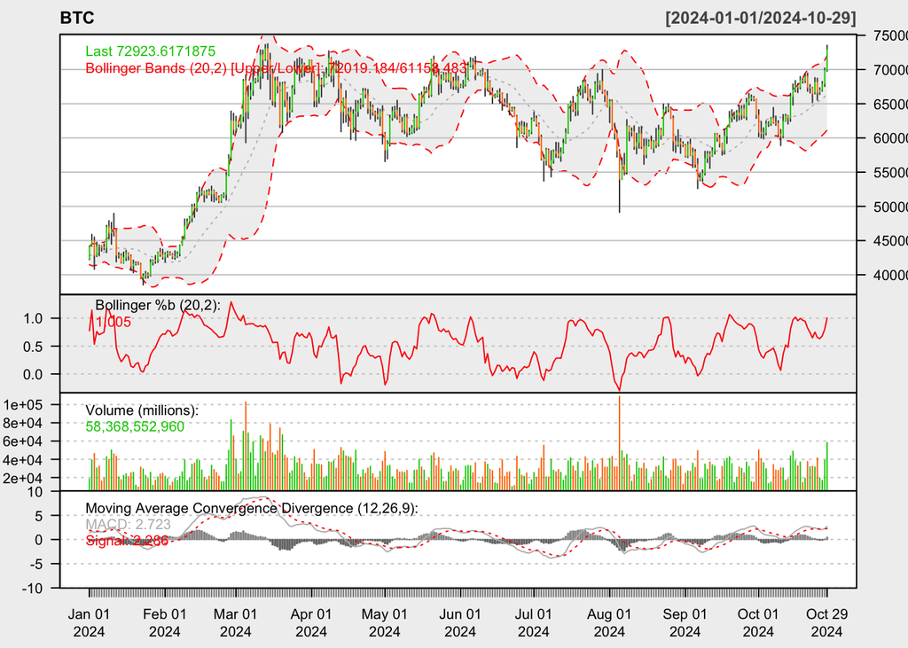

```r
options("getSymbols.warning4.0"=FALSE)

BTC <-getSymbols("BTC-USD", src = "yahoo", auto.assign = FALSE)

BTC <- na.omit(BTC)

chartSeries(BTC,TA='addBBands();
                    addBBands(draw="p");
                    addVo();
                    addMACD()',

              subset='2024',
                theme="white")
```

```r
head(BTC)
```

```
##            BTC-USD.Open BTC-USD.High BTC-USD.Low BTC-USD.Close BTC-USD.Volume
## 2014-09-17      465.864      468.174     452.422       457.334       21056800
## 2014-09-18      456.860      456.860     413.104       424.440       34483200
## 2014-09-19      424.103      427.835     384.532       394.796       37919700
## 2014-09-20      394.673      423.296     389.883       408.904       36863600
## 2014-09-21      408.085      412.426     393.181       398.821       26580100
## 2014-09-22      399.100      406.916     397.130       402.152       24127600
##            BTC-USD.Adjusted
## 2014-09-17          457.334
## 2014-09-18          424.440
## 2014-09-19          394.796
## 2014-09-20          408.904
## 2014-09-21          398.821
## 2014-09-22          402.152
```

Para fines del ejercicio de esta clase, usaremos el valor de la acción ajustado. Esto nos servirá para calcular el rendimiento diario, o puesto en lenguaje de series temporales podemos decir que usaremos la serie en diferencias logarítmicas.

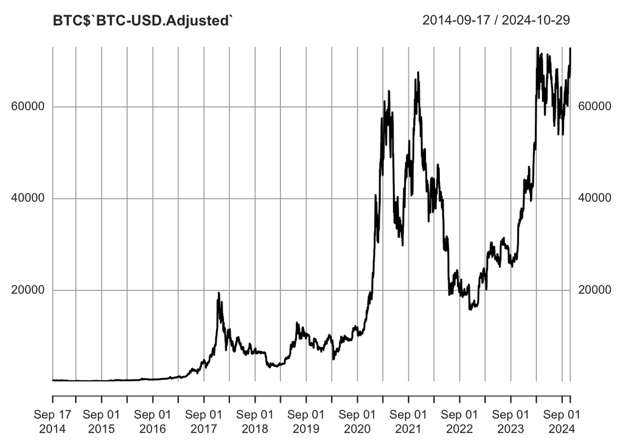

```r
plot(BTC$`BTC-USD.Adjusted`)
```

Una de las preguntas relevantes al observar la serie en diferencias, es si podríamos afirmar que esta serie cumple con el supuesto de homoscedasticidad.

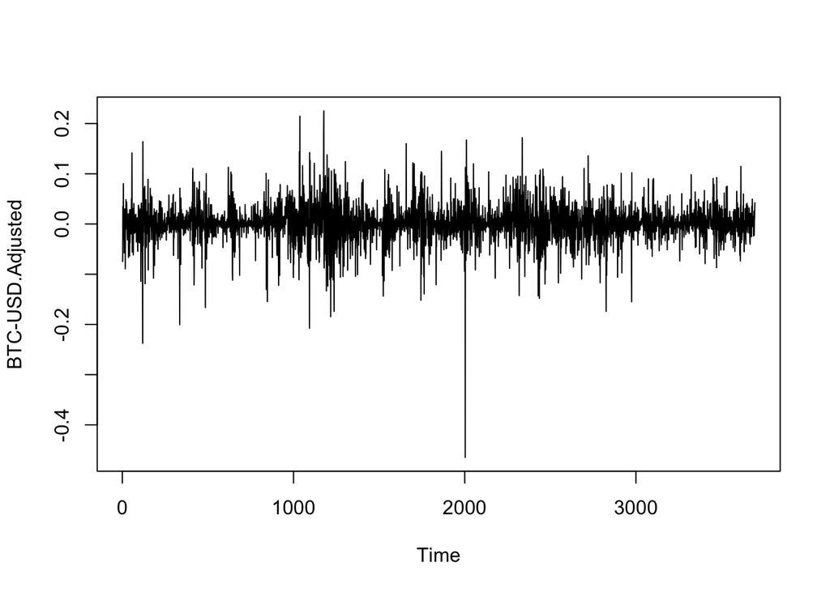

```r
logret <- ts(diff(log(BTC$`BTC-USD.Adjusted`))[-1])

plot(logret)
```

## Value at risk

El Valor en Riesgo, básicamente es un cálculo que nos permite estimar el monto que una acción o portafolio podría perder dada una probabilidad $(1-\alpha)$

```r
alpha <- 0.05
VaR <- quantile(logret, alpha)

round(VaR, 4)
```

```
##      5%
## -0.0581
```

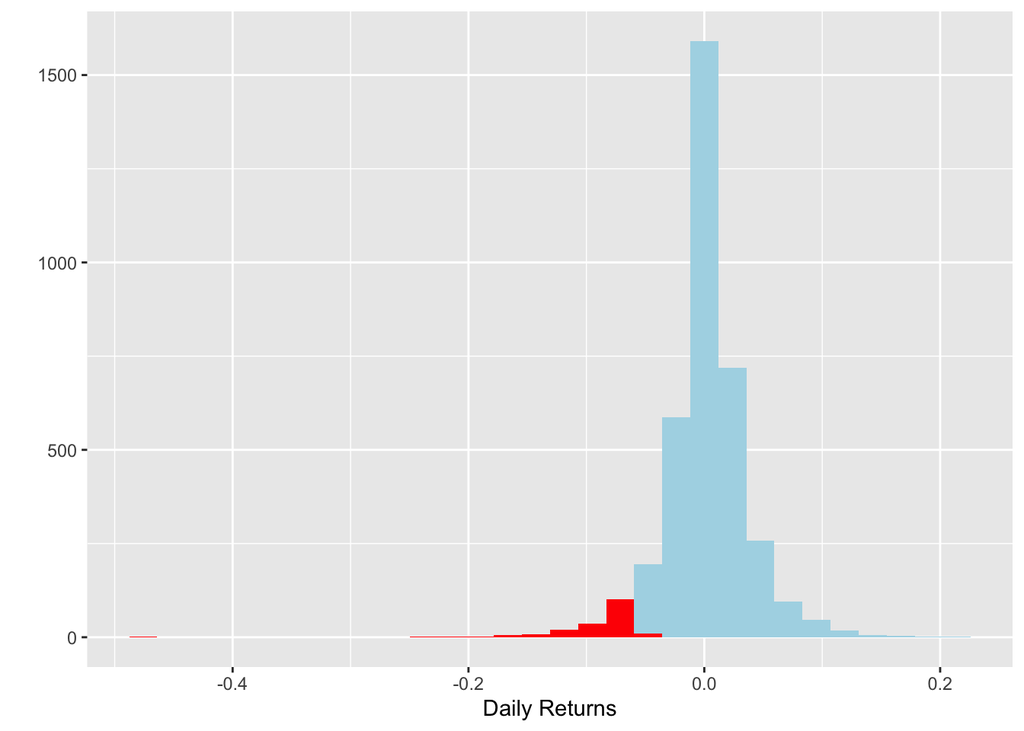

```r
qplot(logret , geom = 'histogram') + geom_histogram(fill = 'lightblue' , bins = 30) +
  geom_histogram(aes(logret[logret < quantile(logret , 0.05)]) , fill = 'red' , bins = 30) +
  labs(x = 'Daily Returns')
```

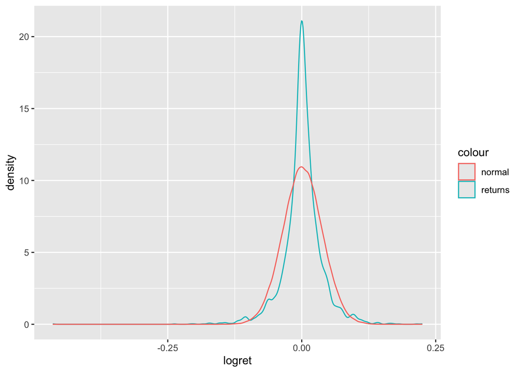

```r
normal_dist <- rnorm(100000, mean(logret), sd(logret))
VaR_n <- quantile(normal_dist, 0.05)
ES_n <- mean(normal_dist[normal_dist<VaR])

ggplot()+
  geom_density(aes(logret, geom ='density', col = 'returns'))+
  geom_density(aes(normal_dist, col = 'normal'))
```

```r
vector_ret <- as.vector(logret)

##Kurtosis
round(kurtosis(vector_ret),2)
```

```
## [1] 14.39
```

```r
##Sesgo
round(skewness(vector_ret),2)
```

```
## [1] -0.73
```

$H_o: K=S=0$

```r
##Prueba de normalidad
jarque.test(vector_ret)
```

```
##
##  Jarque-Bera Normality Test
##
## data:  vector_ret
## JB = 20300, p-value < 2.2e-16
## alternative hypothesis: greater
```

## Calcular VaR para una distribución t

Como sabemos la distribución normal es un caso particular de la distribución t de student, correspondiente a un caso en el que los Grados de Libertad (*df*) tienden a infinito. Mediante el método de máxima verosimilitud nos aproximamos a una distribución t de student que describe mejor el comportamiento de los retornos de este activo.

```r
t.fit <-fitdistr(vector_ret, "t")
round(t.fit$estimate, 6)
```

```
##        m        s       df
## 0.001702 0.019370 2.210607
```

```r
#install.packages("metRology")
library(metRology)
alpha <- 0.05
set.seed(1289)
rvec <- rt.scaled(length(logret), mean=t.fit$estimate[1],
                  sd = t.fit$estimate[2],
                  df = t.fit$estimate[3])

VaR <- quantile(rvec, alpha)
round(VaR, 6)
```

```
##        5%
## -0.047808
```

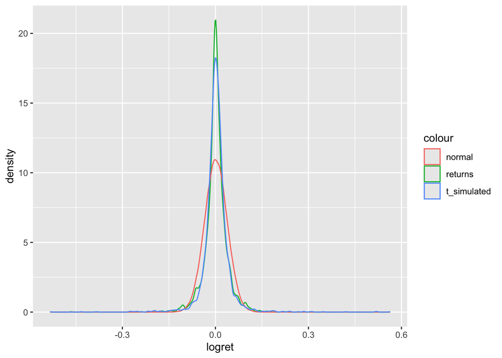

```r
ggplot()+
  geom_density(aes(logret, geom ='density', col = 'returns'))+
  geom_density(aes(normal_dist, col = 'normal'))+
    geom_density(aes(rvec, col = 't_simulated'))
```

# ARCH

Hasta ahora las distribuciones utilizadas para medir el Valor en Riesgo de este activo, asumen que no existe correlación serial en los retornos diarios de este activo. Observemos un par de gráficas de la función de autocorrelación para corroborar este hecho.

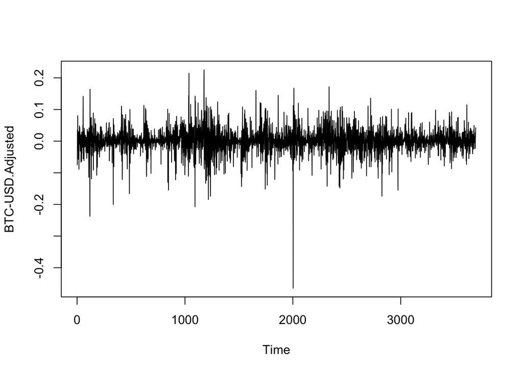

```r
plot(logret)
```

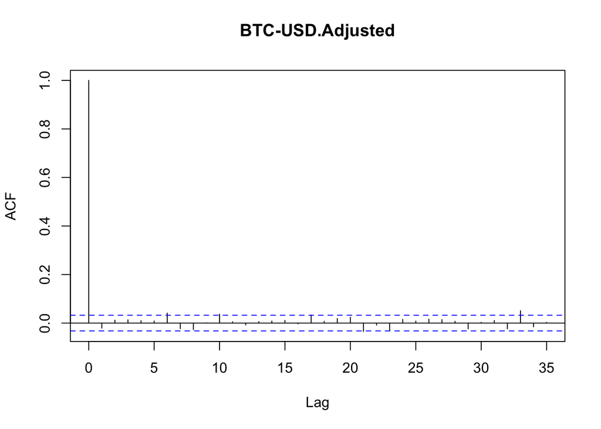

```r
acf(logret)
```

La idea de clusterización de volatilidad, asume que periodos de alta volatilidad serán seguidos por una alta volatilidad y viceversa. Por esta razón la función de autocorrelación útil para saber si existen clusters de volatilidad, es utilizando el valor absoluto, ya que lo que importa es saber si la serie está autocorrelacionada en la magnitud de los movimientos.

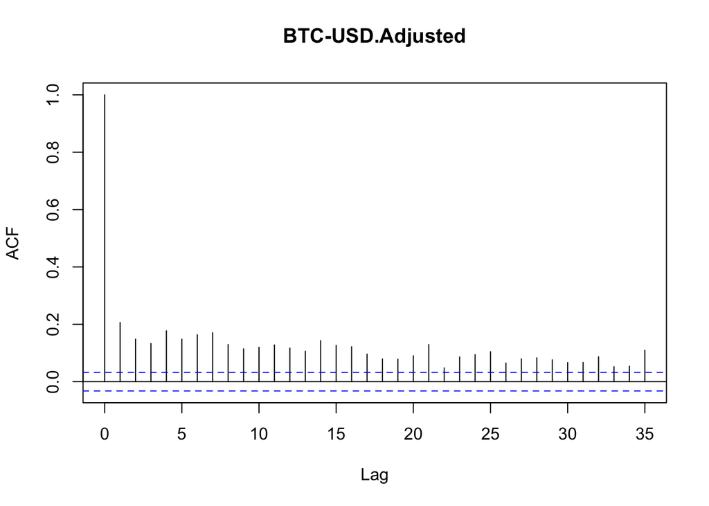

```r
acf(abs(logret))
```

Otra manera de corroborar esta idea, es volviendo IID nuestra serie de datos y observar que de este modo se pierde la autocorrelación serial, lo que refuerza la idea de que en esta serie existen clusters de volatilidad.

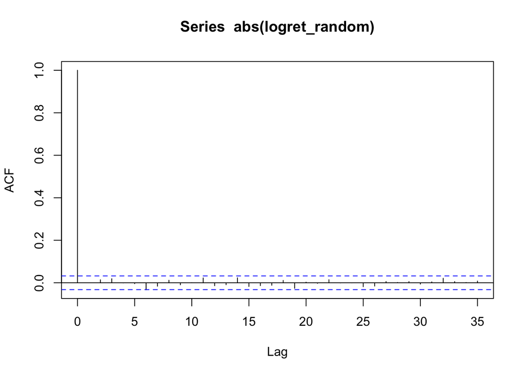

```r
logret_random <- sample(as.vector(logret),size =  length(logret), replace = FALSE)

acf(abs(logret_random))
```

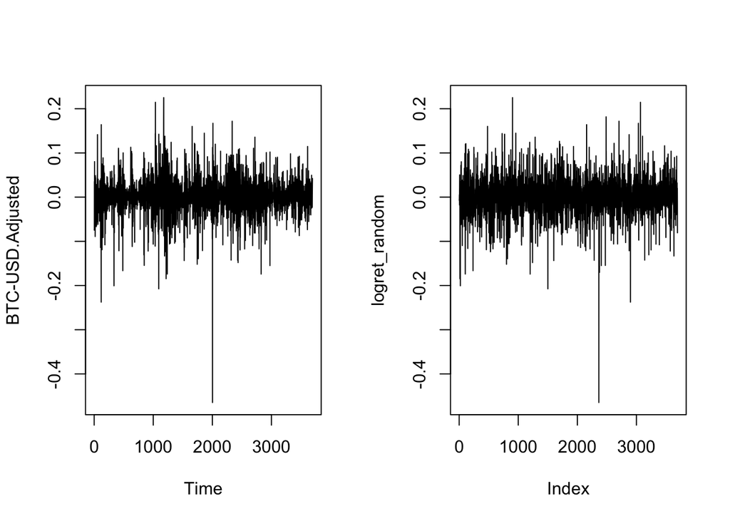

```r
par(mfrow = c(1,2))
plot(logret)
plot(logret_random, type = 'l')
```

Primer enfoque para comprobar aceptar o rechazar la hopótesis de que necesitamos estimar un ARCH(q)

```r
logret_mean = dynlm(logret~1)

summary(logret_mean)
```

```
##
## Time series regression with "ts" data:
## Start = 1, End = 3695
##
## Call:
## dynlm(formula = logret ~ 1)
##
## Residuals:
##      Min       1Q   Median       3Q      Max
## -0.46610 -0.01407 -0.00003  0.01544  0.22375
##
## Coefficients:
##              Estimate Std. Error t value Pr(>|t|)
## (Intercept) 0.0013726  0.0006019   2.281   0.0226 *
## ---
## Signif. codes:  0 '***' 0.001 '**' 0.01 '*' 0.05 '.' 0.1 ' ' 1
##
## Residual standard error: 0.03659 on 3694 degrees of freedom
```

```r
ehatsq = ts(resid(logret_mean)^2)

ARCH_m = dynlm(ehatsq~L(ehatsq))

summary(ARCH_m)
```

```
##
## Time series regression with "ts" data:
## Start = 2, End = 3695
##
## Call:
## dynlm(formula = ehatsq ~ L(ehatsq))
##
## Residuals:
##       Min        1Q    Median        3Q       Max
## -0.016917 -0.001164 -0.001032 -0.000323  0.216088
##
## Coefficients:
##              Estimate Std. Error t value Pr(>|t|)
## (Intercept) 1.164e-03  8.283e-05  14.047  < 2e-16 ***
## L(ehatsq)   1.295e-01  1.632e-02   7.939 2.67e-15 ***
## ---
## Signif. codes:  0 '***' 0.001 '**' 0.01 '*' 0.05 '.' 0.1 ' ' 1
##
## Residual standard error: 0.004856 on 3692 degrees of freedom
## Multiple R-squared:  0.01679,    Adjusted R-squared:  0.01652
## F-statistic: 63.03 on 1 and 3692 DF,  p-value: 2.674e-15
```

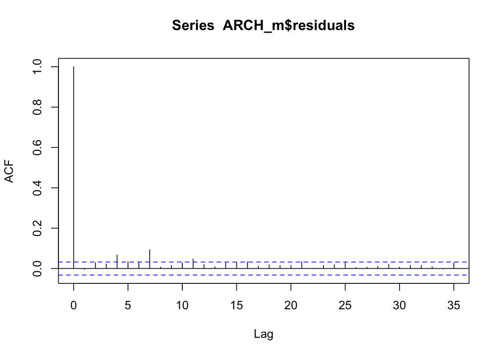

```r
acf(ARCH_m$residuals)
```

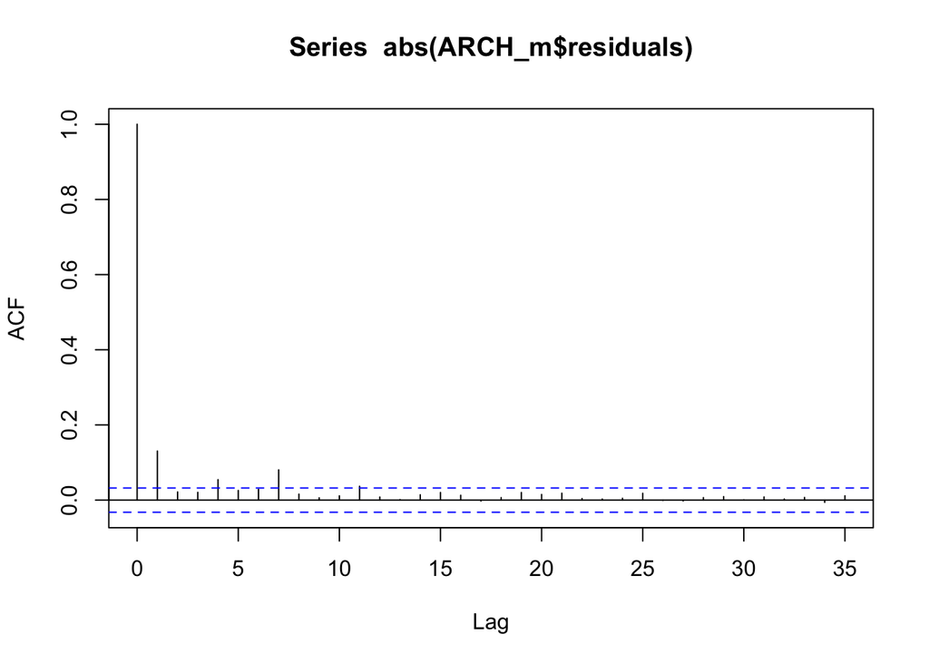

```r
acf(abs(ARCH_m$residuals))
```

```r
ArchTest(logret, lags = 1, demean = TRUE)
```

```
##
##  ARCH LM-test; Null hypothesis: no ARCH effects
##
## data:  logret
## Chi-squared = 62.009, df = 1, p-value = 3.419e-15
```

### ARCH(1)

$Y_t = \mu+\sqrt{h_t}\varepsilon_t$

$h_t = \omega+\alpha_i\varepsilon^2_{t-i}+u_t$

$\varepsilon$~$N(0,1)$

```r
library(rugarch)

auto.arima(logret)
```

```
## Series: logret
## ARIMA(2,0,0) with non-zero mean
##
## Coefficients:
##           ar1     ar2    mean
##       -0.0207  0.0116  0.0014
## s.e.   0.0165  0.0165  0.0006
##
## sigma^2 = 0.001338:  log likelihood = 6982.03
## AIC=-13956.07   AICc=-13956.06   BIC=-13931.21
```

```r
model.spec = ugarchspec(variance.model = list(model = 'sGARCH' , garchOrder = c(1, 0)),
                        mean.model = list(armaOrder = c(2,0)), distribution.model = "std")

arch.fit = ugarchfit(spec = model.spec , data = logret, solver = 'solnp')

arch.fit@fit$matcoef
```

```
##            Estimate   Std. Error    t value     Pr(>|t|)
## mu      0.001612455 0.0003580233  4.5037708 6.675821e-06
## ar1    -0.052550894 0.0162885831 -3.2262410 1.254277e-03
## ar2    -0.001429790 0.0133301121 -0.1072602 9.145826e-01
## omega   0.002037570 0.0005394154  3.7773675 1.584947e-04
## alpha1  0.798080092 0.2465160272  3.2374369 1.206086e-03
## shape   2.326422120 0.1124692009 20.6849707 0.000000e+00
```

```r
boot.garch <- ugarchboot(arch.fit,
                         method = "Partial",
                         sampling = "raw",  #bootstrap from fitted varepsilon
                         n.ahead = 1,          #simulation horizon
                         n.bootpred = 100000, #number of simulations
                         solver = "solnp")

## VaR estimado mediante ARCH
rvec <- boot.garch@fseries
alpha <- 0.05
VaR <- quantile(rvec, alpha)
round(VaR,6)
```

```
##        5%
## -0.068079
```

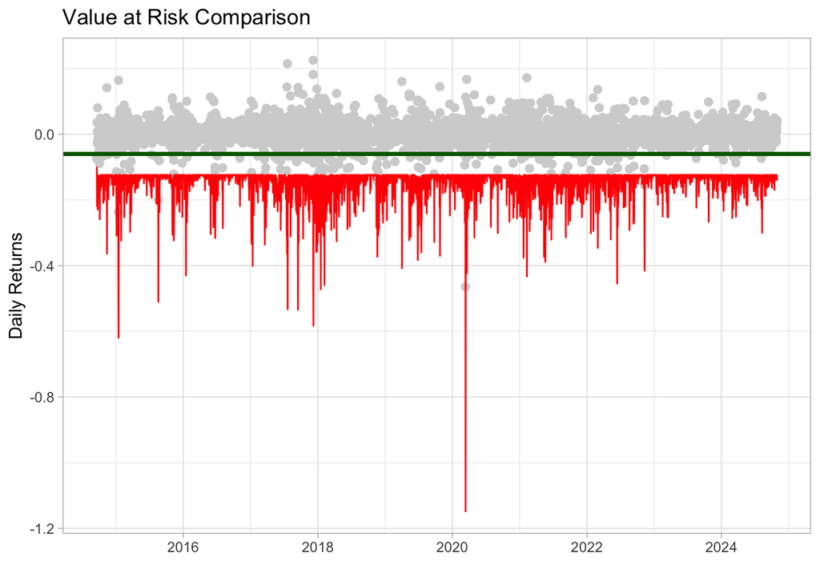

```r
F_inv = qt(0.05, t.fit$estimate[3])

tiempo= time(BTC[-1])

ggplot()+
  geom_point(aes(y = logret,x = tiempo),colour = 'lightgrey' , size = 2) +
  geom_line(aes(y = arch.fit@fit$sigma*(F_inv), x = tiempo), colour = 'red') +
  geom_hline(yintercept = sd(logret)*qnorm(0.05) , colour = 'darkgreen' , size = 1.2) + theme_light() +
  labs(x = '' , y = 'Daily Returns' , title = 'Value at Risk Comparison')
```

## GARCH(0,1)

$Y_t = \mu+\sqrt{h_t}\varepsilon_t$

$h_t = \omega+\beta_ih^2_{t-i}+u_t$

$\varepsilon$~$N(0,1)$

```r
model.spec = ugarchspec(variance.model = list(model = 'sGARCH' , garchOrder = c(0,1)),
                        mean.model = list(armaOrder = c(2,0)), distribution.model = "std")

fit.garch.n = ugarchfit(spec = model.spec, data = logret, solver = "solnp")
fit.garch.n@fit$matcoef
```

```
##            Estimate   Std. Error       t value     Pr(>|t|)
## mu     1.736340e-03 3.771844e-04     4.6034252 4.155985e-06
## ar1   -6.241033e-02 1.384760e-02    -4.5069421 6.576859e-06
## ar2   -4.382884e-03 1.323809e-02    -0.3310812 7.405831e-01
## omega  3.895509e-06 6.431564e-08    60.5686188 0.000000e+00
## beta1  9.981286e-01 3.128370e-05 31905.7067989 0.000000e+00
## shape  2.500507e+00 2.730116e-02    91.5897785 0.000000e+00
```

```r
boot.garch <- ugarchboot(fit.garch.n,
                         method = "Partial",
                         sampling = "raw",  #bootstrap from fitted varepsilon
                         n.ahead = 1,          #simulation horizon
                         n.bootpred = 100000, #number of simulations
                         solver = "solnp")

rvec <- boot.garch@fseries
alpha <- 0.05
VaR <- quantile(rvec, alpha)
VaR
```

```
##          5%
## -0.06241912
```

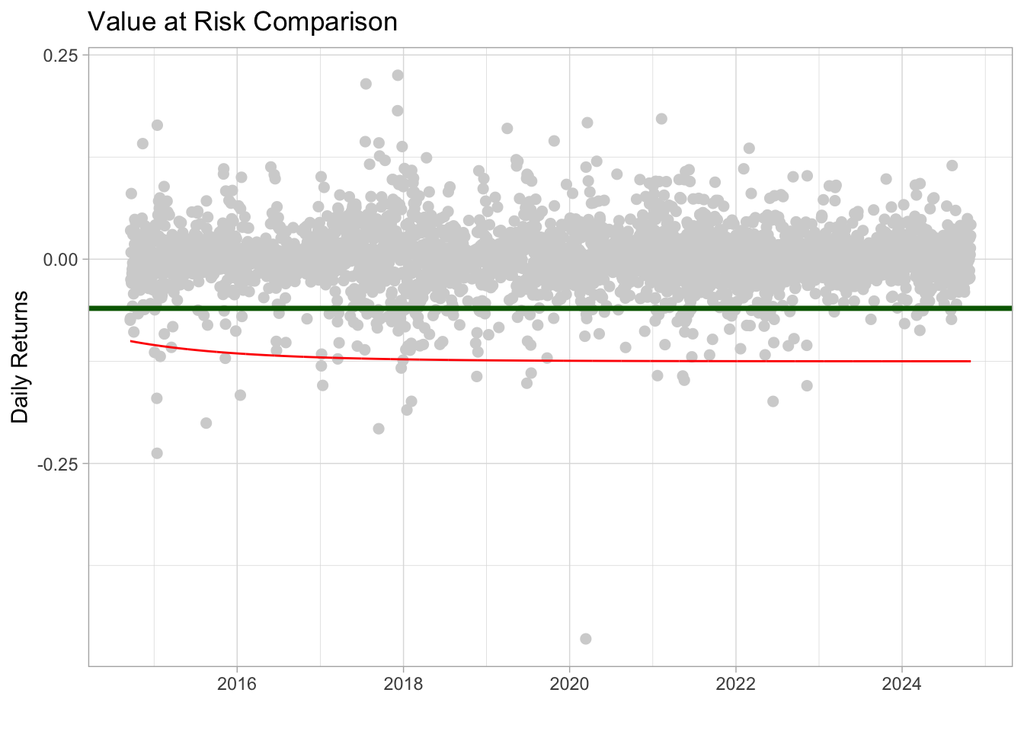

```r
F_inv = qt(0.05, t.fit$estimate[3])

tiempo= time(BTC[-1])

ggplot()+
  geom_point(aes(y = logret,x = tiempo),colour = 'lightgrey' , size = 2) +
  geom_line(aes(y = fit.garch.n@fit$sigma*(F_inv), x = tiempo), colour = 'red') +
  geom_hline(yintercept = sd(logret)*qnorm(0.05) , colour = 'darkgreen' , size = 1.2) + theme_light() +
  labs(x = '' , y = 'Daily Returns' , title = 'Value at Risk Comparison')
```

### Selección GARCH(p,q) óptimo

$Y_t = \mu+\sqrt{h_t}\varepsilon_t$

$h_t = \omega+\beta_ih_{t-i}+\alpha_i\varepsilon^2_{t-i}+u_t$

$\varepsilon$~$N(0,1)$

```r
#Criterios de información

infocriteria(fit.garch.n)
```

```
##
## Akaike       -4.075627
## Bayes        -4.065535
## Shibata      -4.075632
## Hannan-Quinn -4.072035
```

```r
#Selección del modelo óptimo

source("Lag_Opt_GARCH.R")

Lag_Opt_GARCH(ehatsq,4,4)
```

```
##       q p       AIC Optimo
##  [1,] 1 1 -10.92309      0
##  [2,] 1 2 -10.92288      0
##  [3,] 1 3 -10.92518      0
##  [4,] 1 4 -10.92212      0
##  [5,] 2 1 -10.92244      0
##  [6,] 2 2 -10.92295      0
##  [7,] 2 3 -10.92230      0
##  [8,] 2 4 -10.92177      0
##  [9,] 3 1 -10.92189      0
## [10,] 3 2 -10.92241      0
## [11,] 3 3 -10.92472      0
## [12,] 3 4 -10.92128      0
## [13,] 4 1 -10.92454      0
## [14,] 4 2 -10.92568      1
## [15,] 4 3 -10.92567      0
## [16,] 4 4 -10.92515      0
```

```r
# Estimación de modelo óptimo

model.spec = ugarchspec(variance.model = list(model = 'sGARCH' , garchOrder = c(4,2)),
                        mean.model = list(armaOrder = c(2,0)), distribution.model = "std")


model.fit = ugarchfit(spec = model.spec , data = logret, solver = 'solnp')

model.fit@fit$matcoef
```

```
##             Estimate   Std. Error       t value     Pr(>|t|)
## mu      1.338729e-03 3.250997e-04  4.117904e+00 3.823342e-05
## ar1    -5.047846e-02 1.520554e-02 -3.319741e+00 9.010114e-04
## ar2     1.018596e-03 1.399969e-02  7.275852e-02 9.419983e-01
## omega   2.653860e-05 5.274870e-06  5.031139e+00 4.875750e-07
## alpha1  1.340008e-01 2.253948e-02  5.945162e+00 2.761838e-09
## alpha2  3.289333e-07 3.596175e-02  9.146755e-06 9.999927e-01
## alpha3  1.287724e-07 2.650585e-02  4.858262e-06 9.999961e-01
## alpha4  2.854178e-02 2.195543e-02  1.299987e+00 1.936053e-01
## beta1   4.104138e-01 2.211021e-01  1.856218e+00 6.342246e-02
## beta2   4.260431e-01 1.763735e-01  2.415574e+00 1.571043e-02
## shape   3.186140e+00 1.302327e-01  2.446498e+01 0.000000e+00
```

```r
boot.garch <- ugarchboot(model.fit,
                         method = "Partial",
                         sampling = "raw",  #bootstrap from fitted varepsilon
                         n.ahead = 1,          #simulation horizon
                         n.bootpred = 100000, #number of simulations
                         solver = "solnp")

## VaR estimado mediante GARCH óptimo
rvec <- boot.garch@fseries
alpha <- 0.05
VaR <- quantile(rvec, alpha)
VaR
```

```
##          5%
## -0.04214458
```

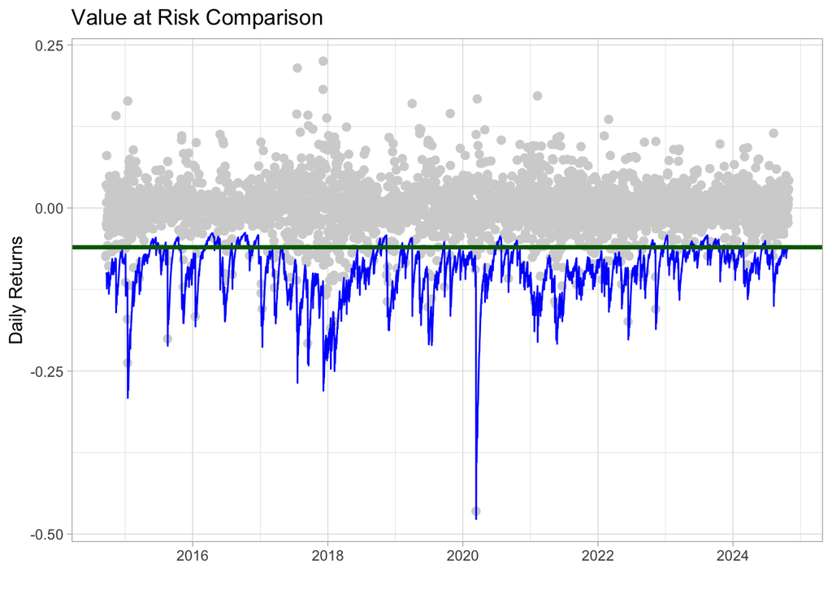

```r
F_inv = qt(0.05, t.fit$estimate[3])

tiempo= time(BTC[-1])

ggplot()+
  geom_point(aes(y = logret,x = tiempo),colour = 'lightgrey' , size = 2) +
  geom_line(aes(y = model.fit@fit$sigma*(F_inv), x = tiempo), colour = 'blue') +
  geom_hline(yintercept = sd(logret)*qnorm(0.05) , colour = 'darkgreen' , size = 1.2) + theme_light() +
  labs(x = '' , y = 'Daily Returns' , title = 'Value at Risk Comparison')
```

### Comparativo entre cálculos

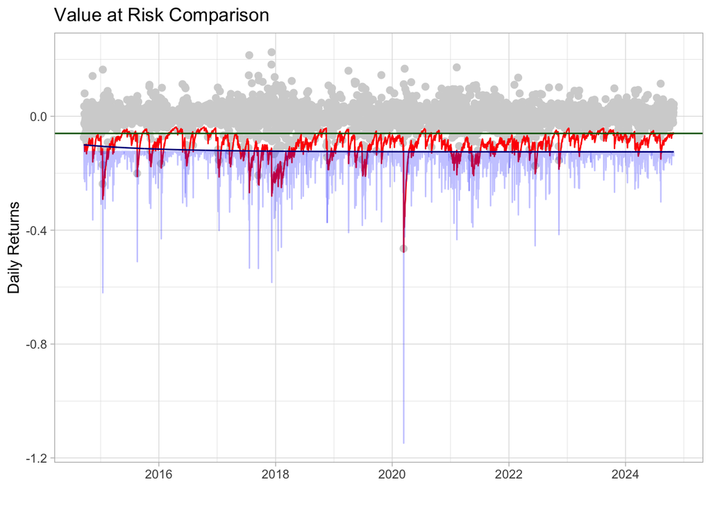

```r
ggplot()+
  geom_point(aes(y = logret,x = tiempo),colour = 'lightgrey' , size = 2) +
  geom_line(aes(y = model.fit@fit$sigma*(F_inv), x = tiempo), colour = 'red') +
  geom_line(aes(y = arch.fit@fit$sigma*(F_inv), x = tiempo), colour = 'blue', alpha = 0.25) +
  geom_line(aes(y = fit.garch.n@fit$sigma*(F_inv), x = tiempo), colour = 'blue4') +
  geom_hline(yintercept = sd(logret)*qnorm(0.05) , colour = 'darkgreen') + theme_light() +
  labs(x = '' , y = 'Daily Returns' , title = 'Value at Risk Comparison')
```

### Forecasting with GARCH(1,1)

Para realizar pronósticos con la estimación de un GARCH, utilizando la librería *rugarch*, es necesario utilizar la función **ugarchforecast()**.

```r
model.spec = ugarchspec(variance.model = list(model = 'sGARCH' , garchOrder = c(1,1)),
                        mean.model = list(armaOrder = c(4,2)), distribution.model = "std")
model.fit = ugarchfit(spec = model.spec , data = logret, solver = 'solnp')
spec = getspec(model.fit)
setfixed(spec) <- as.list(coef(model.fit))
```

Esta función precisa como argumentos nuestra estimación del modelo GARCH, con una modificación en la manera en que se presentan los coeficientes, realizada en la última línea del código anterior y que llamamos *spec*. *n.ahead* es el número de periodos que vamos a pronosticar, *n.roll* señala el número de pronósticos móviles que utilizaremos, en caso de que haya más información para realizar el pronóstico. Finalmente damos como input nuestro set de datos y como producto obtendremos el pronostico de Sigma tanto como de la serie.

```r
forecast = ugarchforecast(spec, n.ahead = 12, n.roll = 0, logret)
sigma(forecast)
```

```
##      3695-01-01
## T+1  0.02577551
## T+2  0.02609848
## T+3  0.02641718
## T+4  0.02673178
## T+5  0.02704240
## T+6  0.02734919
## T+7  0.02765227
## T+8  0.02795177
## T+9  0.02824780
## T+10 0.02854047
## T+11 0.02882988
## T+12 0.02911613
```

```r
fitted(forecast)
```

```
##         3695-01-01
## T+1  -0.0009165399
## T+2   0.0013460810
## T+3   0.0016145464
## T+4   0.0011765288
## T+5   0.0011221917
## T+6   0.0015430065
## T+7   0.0014916511
## T+8   0.0011013253
## T+9   0.0012465249
## T+10  0.0015846126
## T+11  0.0013623883
## T+12  0.0010932760
```

```r
forecast
```

```
##
## *------------------------------------*
## *       GARCH Model Forecast         *
## *------------------------------------*
## Model: sGARCH
## Horizon: 12
## Roll Steps: 0
## Out of Sample: 0
##
## 0-roll forecast [T0=]:
##          Series   Sigma
## T+1  -0.0009165 0.02578
## T+2   0.0013461 0.02610
## T+3   0.0016145 0.02642
## T+4   0.0011765 0.02673
## T+5   0.0011222 0.02704
## T+6   0.0015430 0.02735
## T+7   0.0014917 0.02765
## T+8   0.0011013 0.02795
## T+9   0.0012465 0.02825
## T+10  0.0015846 0.02854
## T+11  0.0013624 0.02883
## T+12  0.0010933 0.02912
```